# Comparison of Fst computations using : `assigner`, `hierfstat`, `strataG`, `diveRsity`, `GENODIVE`.

Thierry Gosselin

2016-11-03

# Prepare your R session

Copy/paste the chunck below

Put this Rmd notebook in the same directory as the data or use `setwd("/YOUR/NEW/PATH/HERE/")`, to change it.

# Why trust assigner ?

Let’s compare `assigner's` Fst calculations (using Weir and Cockerham, 1984), with alternatives.

- use a genomic dataset with thousands of markers so that alternative software stand out
- use `stackr::genomic_converter` to generate the necessary output files:
- the argument `output` allows to use multiple output format at the same time
- `genepop` file for Patrick Meirmans’s `GENODIVE` and Kevin Keenan’s `diveRsity` package
- `hierfstat` object and file for Jérome Goudet’s `hierfstat` package
- `gtypes` object for Eric Archer’s `strataG` package
- `genind` objet for Thibault Jombert’s `adegenet` package
- the funtion will produce a tidy dataset that will be use as input for the fst computation in `assigner`.

The unfiltered vcf was provided by Gregory Owens

Owens GL, Baute GJ, Rieseberg LH. Revisiting a classic case of introgression: hybridization and gene flow in Californian sunflowers. Abbott RJ, Barton NH, Good JM, editors. Molecular Ecology. 2016;25: 2630–2643. doi:10.1111/mec.13569

```r
sunflower <- stackr::genomic_converter(
  data = "sunflower.vcf",
  strata = "sunflower.strata.tsv",
  output = c("genepop", "gtypes", "hierfstat", "genind"),
  filename = "sunflower" # this is optional, stackr can name file based on date/time
)
```

**Number of markers: from 34258 -> 15974 markers, howcome ?**

The function will automatically prune the markers to keep only the markers in common between populations, the default is `common.markers = TRUE`:

- for more info, see function documentation by typing `?stackr::genomic_converter`
- another vignette show the strategy behind using `common.markers = FALSE`. More on this later.

The `sunflower` object created is a list with several objects inside:

```r
names(sunflower)
```

```
[1] "tidy.data"               "hierfstat.no.imputation" "gtypes.no.imputation"    "genind.no.imputation"
```

The object contains the a *tidy dataset*, a *gtypes*, a *genind* and a *hierfstat* objects, without imputation. The *genepop* and *hierfstat* files are in the working directory.

# strataG

- use the `gtypes` object: `sunflower$gtypes.no.imputation`
- results of the analysis are stored in `$pairwise$result`
- use `dplyr::select` to select and rename column headers we need.
- after the command below, take a break (~ 40 min on my MBP)

```r
system.time(
  stratag.fst <- strataG::popStructTest(g = sunflower$gtypes.no.imputation, stats = "fst", type = "pairwise", quietly = TRUE, max.cores = 7, nrep = 0, keep.null = FALSE, write.output = FALSE)$pairwise$result %>%
    dplyr::select(POP1 = strata.1, POP2 = strata.2, STRATAG = Fst)
)
```

```
    user   system  elapsed
2059.691  348.115 2408.696
```

| POP1 | POP2 | STRATAG |
| --- | --- | --- |
| G100 | G102 | 0.09309009 |
| G100 | G103 | 0.15255737 |
| G100 | G108 | 0.27643397 |
| G100 | G109 | 0.18345634 |
| G100 | G111 | 0.23527487 |
| G100 | G118 | 0.09491314 |
| G100 | G122 | 0.16254445 |
| G100 | G124 | 0.23199927 |
| G102 | G103 | 0.08608166 |
| G102 | G108 | 0.22645652 |

[output cut: 26 more lines]

# HIERFSTAT

- Change the name of the `.dat` file in your working directory if you didn’t use the `filename` argument like I did
- After running the code below, get some coffee because it will take some time… (~ 45 min on my MBP)

```r
system.time(
  hierfstat.pairwise.fst <- hierfstat::pairwise.WCfst(
    dat = hierfstat::read.fstat.data(fname = "sunflower.dat"),
    diploid = TRUE
  )
)
```

Work on the matrix:

- we need the pop.id string
- give the matrix rownames and colnames
- fill the diagonal with 0
- transform the matrix into a more useful pairwise df with appropriate column names

| POP1 | POP2 | HIERFSTAT |
| --- | --- | --- |
| G100 | G102 | 0.12286553 |
| G100 | G103 | 0.21004831 |
| G100 | G108 | 0.39421781 |
| G100 | G109 | 0.29864136 |
| G100 | G111 | 0.36911081 |
| G100 | G118 | 0.16851242 |
| G100 | G122 | 0.26862319 |
| G100 | G124 | 0.36575190 |
| G102 | G103 | 0.11806729 |
| G102 | G108 | 0.32227772 |

[output cut: 26 more lines]

# diveRsity

- `package diveRsity` requires the `genepop` file created above
- part of the codes inside the package are optimized with C++!
- no need for a coffee (~ 70 sec on my MBP)

```r
system.time(
  diversity.fst.matrix <- diveRsity::diffCalc(
    infile = "sunflower.gen",
    outfile = "sunflower_diversity",
    fst = TRUE,
    pairwise = TRUE,
    para = TRUE
  )
)
```

```
   user  system elapsed
 67.675   1.329  69.582
```

**Wow! this is very fast**

The results need more work to be useful:

- we need the pop.id string, because population naming from genepop file sucks.
- isolate the divesity matrix object with pairwise info
- give the matrix rownames and colnames
- fill the diagonal and upper matrix with 0
- transform the lower matrix into a more useful pairwise df with appropriate column names

| POP1 | POP2 | DIVERSITY |
| --- | --- | --- |
| G100 | G102 | 0.1232 |
| G100 | G103 | 0.2103 |
| G100 | G108 | 0.3947 |
| G100 | G109 | 0.2991 |
| G100 | G111 | 0.3696 |
| G100 | G118 | 0.1691 |
| G100 | G122 | 0.2696 |
| G100 | G124 | 0.3662 |
| G102 | G103 | 0.1183 |
| G102 | G108 | 0.3225 |

[output cut: 26 more lines]

# GENODIVE

- use the `genepop` file created above
- in `GENODIVE`: Analysis -> Pairwise Differentiation -> Fst with 1 permutations
- Save the matrix content only (no weird pop id or superflous column): genodive.sunflower.tsv
- Import the fst matrix in R, with pop.id string created earlier (`pop.list`), because population naming from genepop file sucks
- no need for a coffee, `GENODIVE` is coded in Objective-C (~ < 3 sec on my MBP)

`GENODIVE` results need more work to be useful: * transform the lower matrix into a more useful pairwise df with appropriate column names

```r
genodive.fst <- stats::na.omit(
  reshape2::melt(
    data = genodive.fst.matrix,
    varnames = c("POP1", "POP2"),
    value.name = "GENODIVE",
    na.rm = TRUE)[reshape2::melt(upper.tri(genodive.fst.matrix, diag = FALSE))$value,]
) %>%
  tibble::as_data_frame() %>%
  dplyr::mutate_at(.cols = c("POP1", "POP2"), .funs = as.character) %>%
  dplyr::arrange(POP1, POP2)
# remove unwanted object
rm(genodive.fst.matrix)
genodive.fst
```

| POP1 | POP2 | GENODIVE |
| --- | --- | --- |
| G100 | G102 | 0.11514310 |
| G100 | G103 | 0.21452835 |
| G100 | G108 | 0.39006723 |
| G100 | G109 | 0.28718161 |
| G100 | G111 | 0.35539815 |
| G100 | G118 | 0.15631869 |
| G100 | G122 | 0.25484860 |
| G100 | G124 | 0.36199759 |
| G102 | G103 | 0.11544083 |
| G102 | G108 | 0.31893321 |

[output cut: 26 more lines]

# ASSIGNER

```r
assigner.fst.results <- assigner::fst_WC84(data = sunflower$tidy.data, pairwise = TRUE, verbose = TRUE)
```

```
#######################################################################
######################### assigner::fst_WC84 ##########################
#######################################################################
```

```
Importing data
Computing global fst
Computing paiwise fst
```

```
############################### RESULTS ###############################
```

```
Fst (overall): 0.263665371
Computation time: 152 sec
```

```
#######################################################################
```

If you want to see the distribution of overall Fst values:

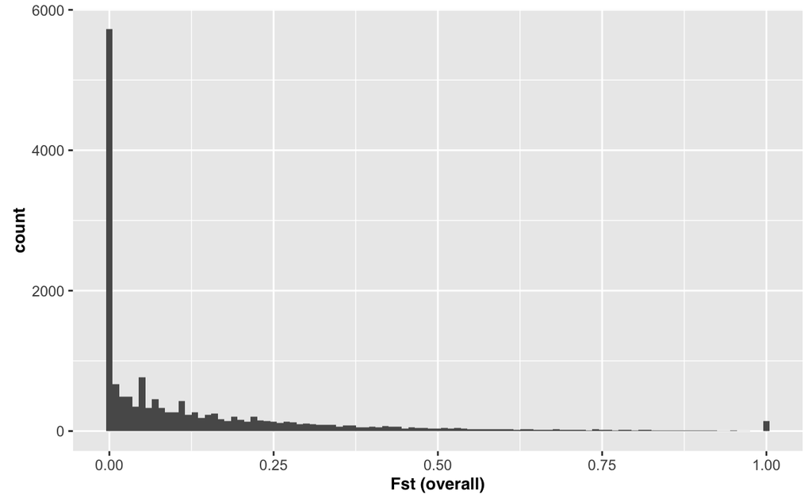

Interested in the Fst overall values:

| FST | N_MARKERS |
| --- | --- |
| 0.2636654 | 15974 |

If you run the function with `ci = TRUE` and give higher number of iterations e.g. `iteration.ci = 10000` you’ll get decent confidence intervals with global and pariwise Fst estimates.

Transfer the pairwise results in a separate df

| POP1 | POP2 | ASSIGNER | N_MARKERS |
| --- | --- | --- | --- |
| G100 | G102 | 0.12286553 | 15974 |
| G100 | G103 | 0.21004831 | 15974 |
| G100 | G108 | 0.39421781 | 15974 |
| G100 | G109 | 0.29864136 | 15974 |
| G100 | G111 | 0.36911081 | 15974 |
| G100 | G118 | 0.16851242 | 15974 |
| G100 | G122 | 0.26862319 | 15974 |
| G100 | G124 | 0.36575190 | 15974 |
| G102 | G103 | 0.11806729 | 15974 |
| G102 | G108 | 0.32227772 | 15974 |

[output cut: 26 more lines]

# SUMMARY

Join all the result together in one table:

| POP1 | POP2 | ASSIGNER | HIERFSTAT | STRATAG | DIVERSITY | GENODIVE |
| --- | --- | --- | --- | --- | --- | --- |
| G100 | G102 | 0.12286553 | 0.12286553 | 0.09309009 | 0.1232 | 0.11514310 |
| G100 | G103 | 0.21004831 | 0.21004831 | 0.15255737 | 0.2103 | 0.21452835 |
| G100 | G108 | 0.39421781 | 0.39421781 | 0.27643397 | 0.3947 | 0.39006723 |
| G100 | G109 | 0.29864136 | 0.29864136 | 0.18345634 | 0.2991 | 0.28718161 |
| G100 | G111 | 0.36911081 | 0.36911081 | 0.23527487 | 0.3696 | 0.35539815 |
| G100 | G118 | 0.16851242 | 0.16851242 | 0.09491314 | 0.1691 | 0.15631869 |
| G100 | G122 | 0.26862319 | 0.26862319 | 0.16254445 | 0.2696 | 0.25484860 |
| G100 | G124 | 0.36575190 | 0.36575190 | 0.23199927 | 0.3662 | 0.36199759 |
| G102 | G103 | 0.11806729 | 0.11806729 | 0.08608166 | 0.1183 | 0.11544083 |
| G102 | G108 | 0.32227772 | 0.32227772 | 0.22645652 | 0.3225 | 0.31893321 |

[output cut: 26 more lines]

Correlation between `assigner` and `hierfstat` speaks for itself:

```r
stats::cor(x = fst.summary$HIERFSTAT, y = fst.summary$ASSIGNER, use = "complete.obs")
```

```
[1] 1
```

Notes:

- the warning: `joining character vector and factor, coercing into character vector` is normal.
- you could go and look at the 36 pairwise comparisons, but the end of the story is very simple: `assigner` and `hierfstat` have equal values down to a very large number of decimals.
- `diveRsity` gives Fst values very close to `assigner` and `hierfstat`.
- `strataG` usually gives downward values
- `GENODIVE` are very close to `assigner` and `hierfstat` with a small downward bias.

Let’s plot the results, but first transform the data into a tidy df:

| PAIRS | SOFTWARE | FST |
| --- | --- | --- |
| G100-G102 | ASSIGNER | 0.12286553 |
| G100-G103 | ASSIGNER | 0.21004831 |
| G100-G108 | ASSIGNER | 0.39421781 |
| G100-G109 | ASSIGNER | 0.29864136 |
| G100-G111 | ASSIGNER | 0.36911081 |
| G100-G118 | ASSIGNER | 0.16851242 |
| G100-G122 | ASSIGNER | 0.26862319 |
| G100-G124 | ASSIGNER | 0.36575190 |
| G102-G103 | ASSIGNER | 0.11806729 |
| G102-G108 | ASSIGNER | 0.32227772 |

[output cut: 170 more lines]

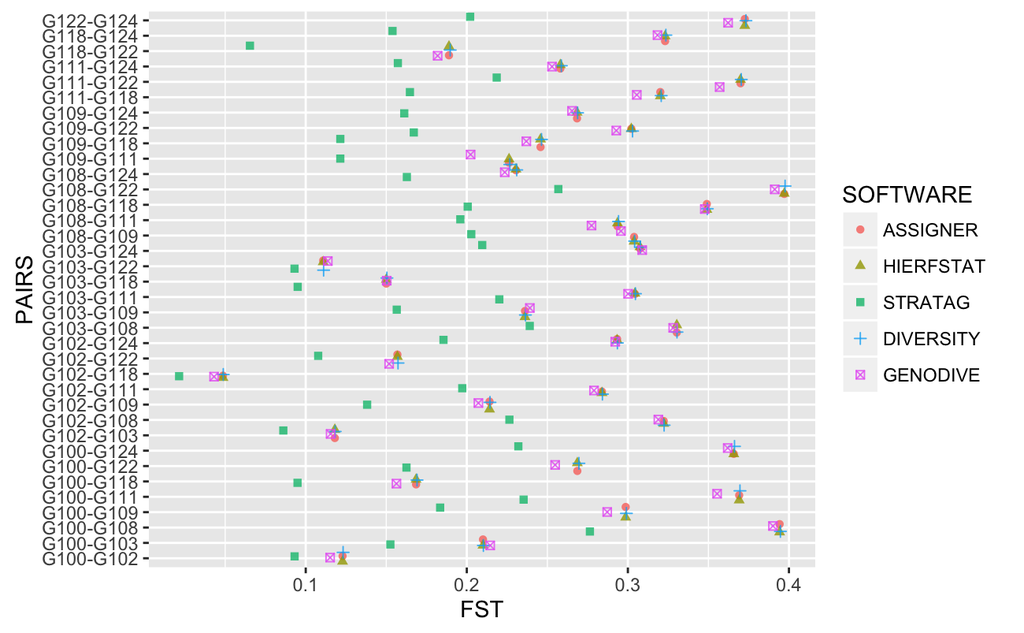